# ONE COMMUNITY MANAGER, TWO CANDIDATES

Bea Sánchez (BS) y Alberto Mayol (AM) son dos candidatos del mismo conglomerado, el Frente Amplio (FA), compitiendo por ser el candidato presidencial de dicho grupo. Ambos hacen campañas en internet y tiene su propios medios, en el contexto de una mayor campaña que enfrentara a FA con otros conglomerados. Pero en esta primaria…a quién apoya el community manager del FA?

```r
FA<-getPage(page = "FrenteAmpliodeChile", token = tok, n = 3000)
```

```
## 25 posts 50 posts 75 posts 100 posts 125 posts 150 posts 175 posts 200 posts 225 posts 250 posts 275 posts 300 posts 325 posts 350 posts 375 posts 400 posts 425 posts 450 posts 475 posts 500 posts 525 posts 550 posts 575 posts 600 posts 625 posts 650 posts 675 posts 700 posts 725 posts 745 posts
```

Ok, tenemos las 745 publicaciones del community manager del FA en Facebook. Primero clasificaremos los post si se refieren a AM, a BS, a ambos o a ninguno.

```r
posteo<-vector()

for (i in 1:length(FA$message)) {
  if ((grepl("mayol", FA$message[i], ignore.case = T) | grepl("alberto", FA$message[i], ignore.case = T)) && (grepl("bea", FA$message[i], ignore.case = T) | grepl("s.nchez", FA$message[i], ignore.case = T))) {
    posteo<-c(posteo,"Ambos")
  } else if (grepl("mayol", FA$message[i], ignore.case = T)|grepl("alberto", FA$message[i], ignore.case = T)) {
    posteo<-c(posteo,"Mayol")
  } else if (grepl("s.nchez", FA$message[i], ignore.case = T)|grepl("bea", FA$message[i], ignore.case = T)) {
    posteo<-c(posteo,"Bea")
  } else {
    posteo<-c(posteo,"Ninguno")
  }
}

FA$posteo<-posteo
```

Ahora calcularemos la cantidad de posteos por cantidato y la extensión promedio de cada texto como indicadores de preferencia.

Para contar palabras primero retiramos puntuación y espacios dobles.

```r
FA$message2<-str_replace_all(FA$message, pattern = "[[:punct:]]", " ")
FA$message2<-str_replace_all(FA$message2, "  ", " ")
FA$lista<-sapply(FA$message2, function(x) {strsplit(x = x,split = " ")})

FA$cuenta<-sapply(FA$lista, length)
extension<-aggregate(FA$cuenta, list(FA$posteo), mean)
cantidad<-aggregate(FA$cuenta, list(FA$posteo), length)
```

### El resultado es:

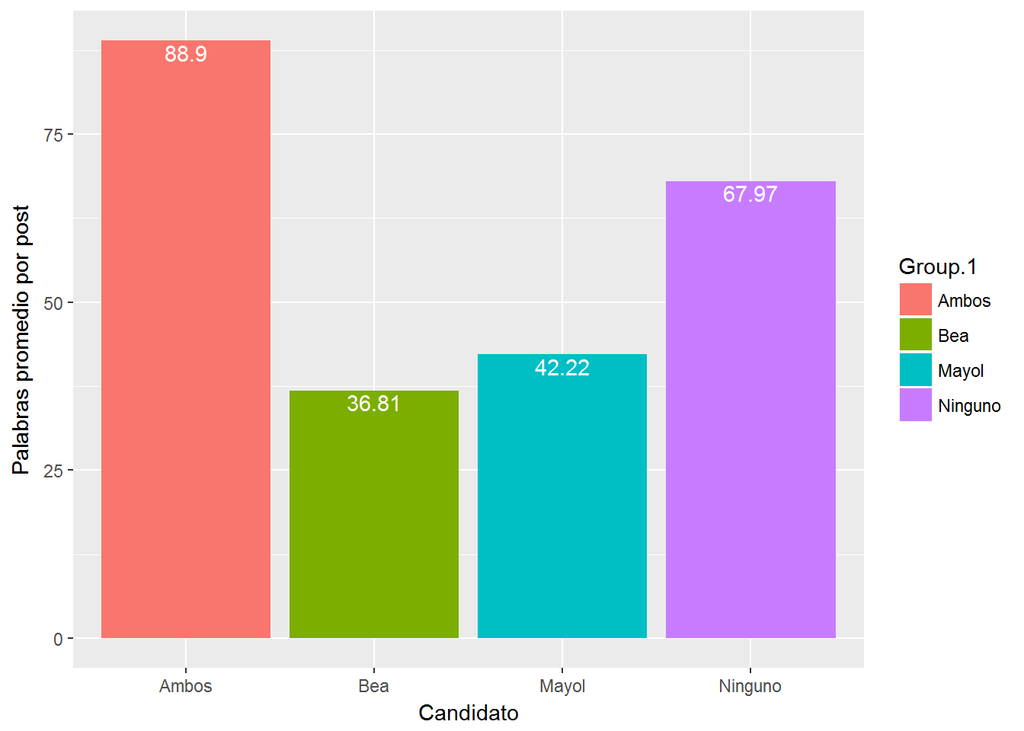

```r
ggplot(extension, aes(x=Group.1,y=x, fill=Group.1), label = Group.1)+geom_col()+ xlab("Candidato") + ylab("Palabras promedio por post")+ geom_text(aes(label=round(x,2)), color= "white", vjust=1.2)
```

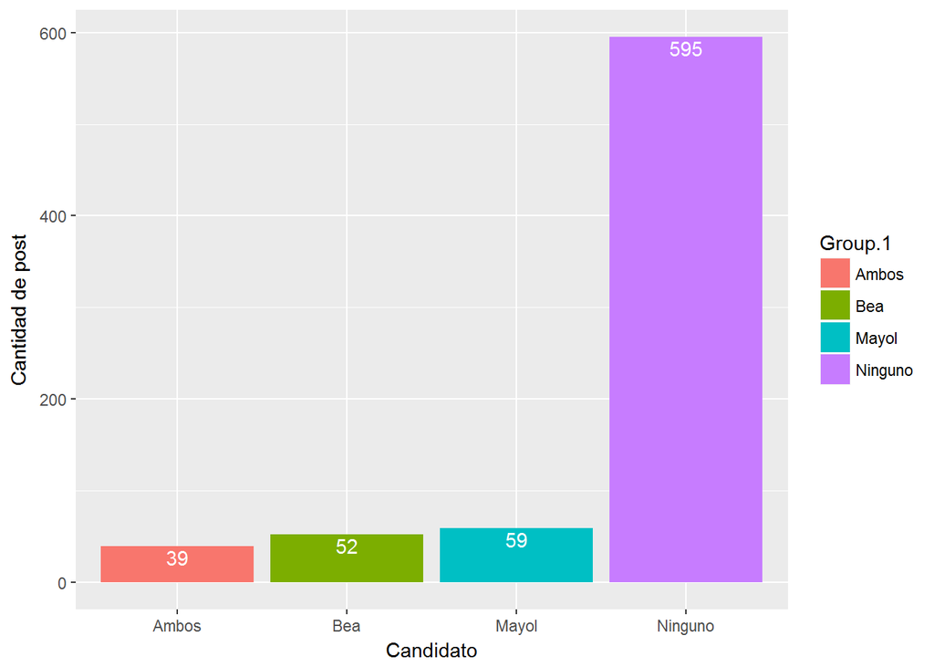

```r
ggplot(cantidad, aes(x=Group.1,y=x, fill=Group.1), label = Group.1)+geom_col()+ xlab("Candidato") + ylab("Cantidad de post")+ geom_text(aes(label=round(x,2)), color= "white", vjust=1.2)
```

Aparentemente hay una ligera preferencia por Mayol, sin embargo Mayol se lanzò antes que Bea de candidata. Veamos como distribuye en el tiempo.

```r
FA$created_time<-as.Date(FA$created_time)
tiempo<-aggregate(FA$cuenta, list(FA$created_time,FA$posteo), length)
```

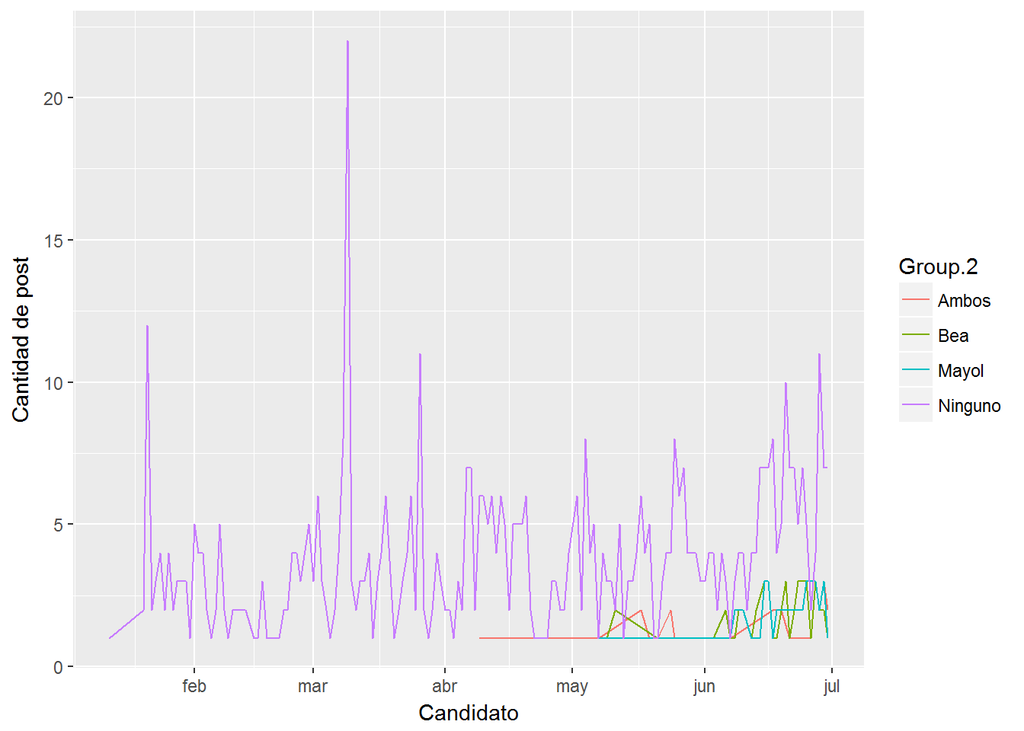

```r
ggplot(tiempo, aes(x=Group.1, y=x, group=Group.2, colour=Group.2))+geom_line()+ xlab("Candidato") + ylab("Cantidad de post")
```

Ok, los post por ninguno dan mucho ruido para apreciar el gráfico, saquémoslos.

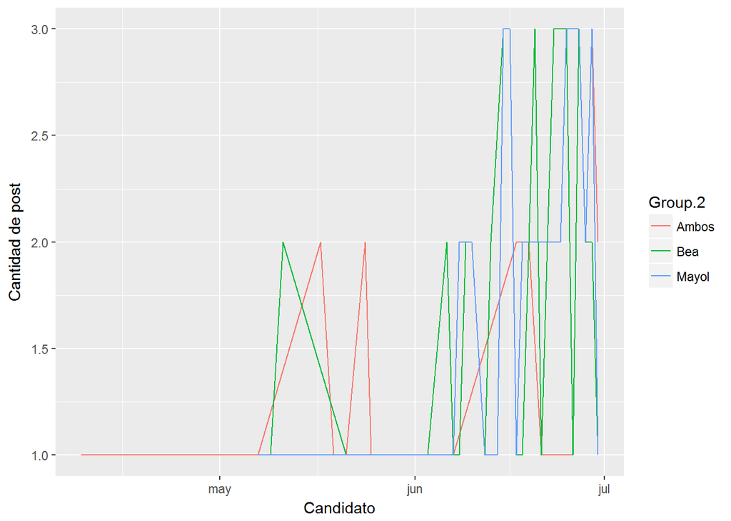

```r
tiempo2<-tiempo[tiempo$Group.2 != "Ninguno",]

ggplot(tiempo2, aes(x=Group.1, y=x, group=Group.2, colour=Group.2))+geom_line()+ xlab("Candidato") + ylab("Cantidad de post")
```

No parece haber una diferencia notable en el tiempo. Aparentemente si hay algun sesgo.

Para confirmarlo debiesemos aplicar algún test estadístico, almenos contra el promedio de palabras utilizados. .

```r
bea<-FA$cuenta[FA$posteo == "Bea"]
mayol<-FA$cuenta[FA$posteo == "Mayol"]
ambos<-FA$cuenta[FA$posteo == "Ambos"]

FA3<-FA[FA$posteo != "Ninguno",]

t.test(bea,mayol)
```

```
##
##  Welch Two Sample t-test
##
## data:  bea and mayol
## t = -0.92478, df = 101.51, p-value = 0.3573
## alternative hypothesis: true difference in means is not equal to 0
## 95 percent confidence interval:
##  -17.022530   6.197236
## sample estimates:
## mean of x mean of y
##  36.80769  42.22034
```

Mmmm, con un p-value de 0.3, no es significativo. Pero acá hay algo extraño, supusimos que la cantidad de palabras por poteo distribuía normal. Let’s check that.

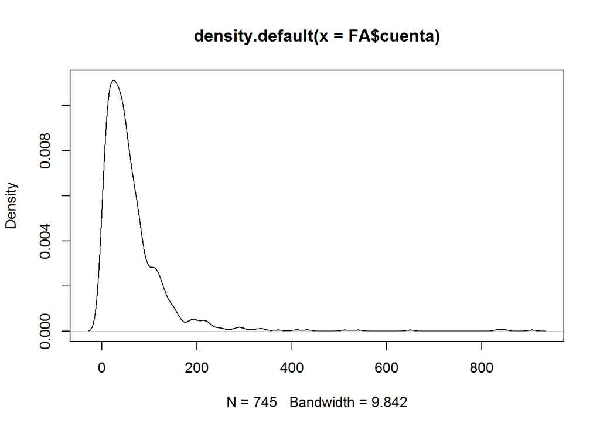

```r
plot(density(FA$cuenta))
```

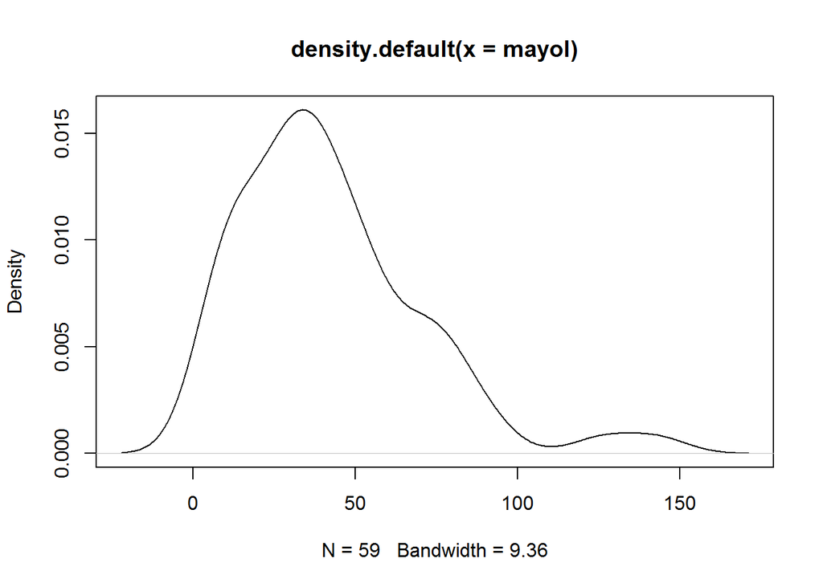

```r
plot(density(mayol))
```

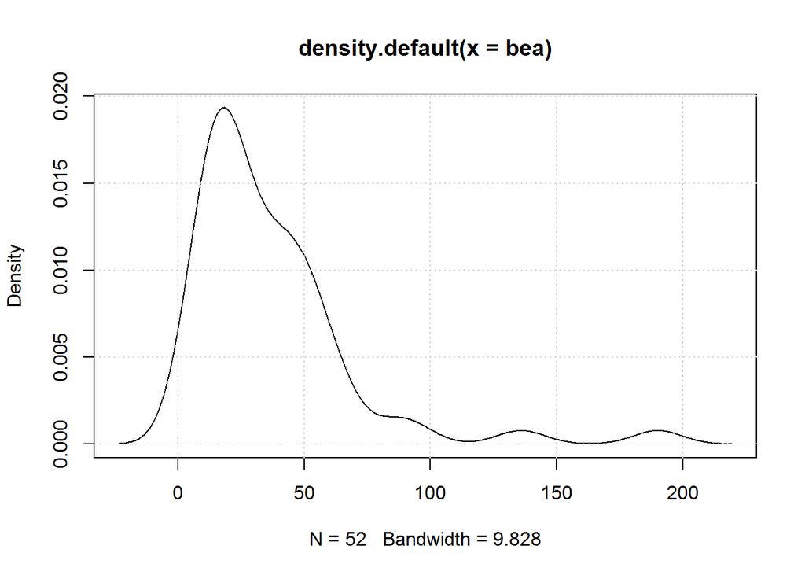

```r
plot(density(bea))
grid()
```

ok, están algo lejos de distribuir normal, de hecho tiene sentido que sigan la ley de Zipf. Esto significa que mejor indicador es la mediana antes que el promedio y que posiblemente deberíamos usar otro tipo de test. Pero primero coparemos las medianas:

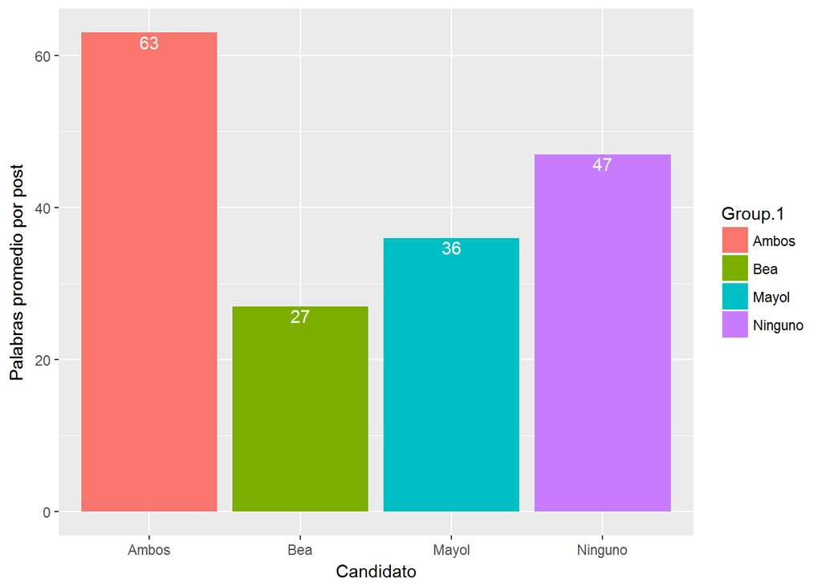

```r
extension2<-aggregate(FA$cuenta, list(FA$posteo), median)
ggplot(extension2, aes(x=Group.1,y=x, fill=Group.1), label = Group.1)+geom_col()+ xlab("Candidato") + ylab("Palabras promedio por post")+ geom_text(aes(label=round(x,2)), color= "white", vjust=1.2)
```

### El contenido de ninguno

Por otra parte hay un monton de publicaciones (580+) que no hacen referencia a ningún candidato en particular ¿Cuál es el contenido de estos post?. Hagamos modelamiento de tópicos para ver de se trata.

```r
FA2<-FA[FA$posteo == "Ninguno",]
ninguno<-FA2$message
matrixEX <- create_matrix(ninguno, language="spanish", removeNumbers=TRUE, stemWords=F, removeStopwords = T, stripWhitespace = T, weighting = tm::weightTf)

rowTotals <- apply(matrixEX , 1, sum)
matrixEX2   <- matrixEX[rowTotals> 0, ]

ldaEX <- LDA(matrixEX2, 20, method = "Gibbs")
terms(ldaEX, 6)
```

```
##      Topic 1       Topic 2                 Topic 3       Topic 4
## [1,] "chile"       "primarias"             "chile"       "trabajadores"
## [2,] "todas"       "primariasfrenteamplio" "universidad" "afp"
## [3,] "invitamos"   "julio"                 "derecho"     "maÃ"
## [4,] "transformar" "presidenciales"        "derechos"    "sistema"
## [5,] "pueden"      "votar"                 "miles"       "ana"
## [6,] "solo"        "gracias"               "sociales"    "domingo"
##      Topic 5         Topic 6       Topic 7  Topic 8    Topic 9
## [1,] "polÃ"          "polÃ"        "debate" "econÃ"    "nueva"
## [2,] "tica"          "sociales"    "asÃ"    "ser"      "niÃ"
## [3,] "hacer"         "tica"        "medios" "millones" "familias"
## [4,] "transformaciÃ" "social"      "estÃ"   "empresas" "columna"
## [5,] "debe"          "alternativa" "dos"    "mico"     "comunidades"
## [6,] "manera"        "construir"   "toda"   "modelo"   "tan"
##      Topic 10     Topic 11   Topic 12       Topic 13     Topic 14
```

[output cut: 20 more lines]